# DS2 Lab2 - Tree-based methods

Data Science 2: Machine Learning Tools - CEU 2021

Janos K. Divenyi, Jeno Pal

2021-03-01

```r
library(tidyverse)
library(ggplot2)
theme_set(theme_minimal())

library(h2o)
h2o.init()
```

```
##  Connection successful!
##
## R is connected to the H2O cluster:
##     H2O cluster uptime:         1 hours 55 minutes
##     H2O cluster timezone:       Europe/Budapest
##     H2O data parsing timezone:  UTC
##     H2O cluster version:        3.32.0.4
##     H2O cluster version age:    1 month
##     H2O cluster name:           H2O_started_from_R_jdivenyi_ikv400
##     H2O cluster total nodes:    1
##     H2O cluster total memory:   7.11 GB
##     H2O cluster total cores:    8
##     H2O cluster allowed cores:  8
##     H2O cluster healthy:        TRUE
##     H2O Connection ip:          localhost
##     H2O Connection port:        54321
##     H2O Connection proxy:       NA
##     H2O Internal Security:      FALSE
##     H2O API Extensions:         Amazon S3, XGBoost, Algos, AutoML, Core V3, TargetEncoder, Core V4
##     R Version:                  R version 4.0.3 (2020-10-10)
```

```r
h2o.no_progress()
```

## Random forests

You covered decision trees in DA3. Using it as a base model lets us build many different models with less variance and better predictive power. The downside: interpretation gets harder.

Idea: as individual trees are unstable and have high variance, train many versions on bootstrap samples (“Bagging”: Bootstrap AGGregation). Then predict: take the average (regression), majority vote / class share (classification).

Random forests: randomly constrain the set of predictor variables used to grow trees (randomly select at each split). Goal: avoid correlated trees that are very similar to each other, still with the aim of decreasing variance.

```r
data <- as_tibble(ISLR::Hitters)
skimr::skim(data)
```

Data summary

| Name | data |
| --- | --- |
| Number of rows | 322 |
| Number of columns | 20 |
| _______________________ |  |
| Column type frequency: |  |
| factor | 3 |
| numeric | 17 |
| ________________________ |  |
| Group variables | None |

**Variable type: factor**

| skim_variable | n_missing | complete_rate | ordered | n_unique | top_counts |
| --- | --- | --- | --- | --- | --- |
| League | 0 | 1 | FALSE | 2 | A: 175, N: 147 |
| Division | 0 | 1 | FALSE | 2 | W: 165, E: 157 |
| NewLeague | 0 | 1 | FALSE | 2 | A: 176, N: 146 |

**Variable type: numeric**

| skim_variable | n_missing | complete_rate | mean | sd | p0 | p25 | p50 | p75 | p100 | hist |
| --- | --- | --- | --- | --- | --- | --- | --- | --- | --- | --- |
| AtBat | 0 | 1.00 | 380.93 | 153.40 | 16.0 | 255.25 | 379.5 | 512.00 | 687 | ▁▇▇▇▅ |
| Hits | 0 | 1.00 | 101.02 | 46.45 | 1.0 | 64.00 | 96.0 | 137.00 | 238 | ▃▇▆▃▁ |
| HmRun | 0 | 1.00 | 10.77 | 8.71 | 0.0 | 4.00 | 8.0 | 16.00 | 40 | ▇▃▂▁▁ |
| Runs | 0 | 1.00 | 50.91 | 26.02 | 0.0 | 30.25 | 48.0 | 69.00 | 130 | ▅▇▆▃▁ |
| RBI | 0 | 1.00 | 48.03 | 26.17 | 0.0 | 28.00 | 44.0 | 64.75 | 121 | ▃▇▃▃▁ |
| Walks | 0 | 1.00 | 38.74 | 21.64 | 0.0 | 22.00 | 35.0 | 53.00 | 105 | ▅▇▅▂▁ |
| Years | 0 | 1.00 | 7.44 | 4.93 | 1.0 | 4.00 | 6.0 | 11.00 | 24 | ▇▆▃▂▁ |
| CAtBat | 0 | 1.00 | 2648.68 | 2324.21 | 19.0 | 816.75 | 1928.0 | 3924.25 | 14053 | ▇▃▂▁▁ |
| CHits | 0 | 1.00 | 717.57 | 654.47 | 4.0 | 209.00 | 508.0 | 1059.25 | 4256 | ▇▃▁▁▁ |
| CHmRun | 0 | 1.00 | 69.49 | 86.27 | 0.0 | 14.00 | 37.5 | 90.00 | 548 | ▇▁▁▁▁ |
| CRuns | 0 | 1.00 | 358.80 | 334.11 | 1.0 | 100.25 | 247.0 | 526.25 | 2165 | ▇▂▁▁▁ |
| CRBI | 0 | 1.00 | 330.12 | 333.22 | 0.0 | 88.75 | 220.5 | 426.25 | 1659 | ▇▂▁▁▁ |
| CWalks | 0 | 1.00 | 260.24 | 267.06 | 0.0 | 67.25 | 170.5 | 339.25 | 1566 | ▇▂▁▁▁ |
| PutOuts | 0 | 1.00 | 288.94 | 280.70 | 0.0 | 109.25 | 212.0 | 325.00 | 1378 | ▇▃▁▁▁ |
| Assists | 0 | 1.00 | 106.91 | 136.85 | 0.0 | 7.00 | 39.5 | 166.00 | 492 | ▇▂▁▁▁ |
| Errors | 0 | 1.00 | 8.04 | 6.37 | 0.0 | 3.00 | 6.0 | 11.00 | 32 | ▇▅▂▁▁ |
| Salary | 59 | 0.82 | 535.93 | 451.12 | 67.5 | 190.00 | 425.0 | 750.00 | 2460 | ▇▃▁▁▁ |

```r
# goal: predict log salary
data <- as_tibble(ISLR::Hitters) %>%
  drop_na(Salary) %>%
  mutate(log_salary = log(Salary), Salary = NULL)

h2o_data <- as.h2o(data)
my_seed <- 20210301
```

```r
splitted_data <- h2o.splitFrame(h2o_data, ratios = c(0.6, 0.2), seed = my_seed)
data_train <- splitted_data[[1]]
data_valid <- splitted_data[[2]]
data_test <- splitted_data[[3]]
```

Let’s see benchmarks: a linear model and a simple regression tree. Let’s use MAE as our main performance metric. For log outcomes, MAE gives you about the typical size of the percentage error of the original outcome (here: salary).

```r
y <- "log_salary"
X <- setdiff(names(h2o_data), y)

# lambda = 0 corresponds to simple OLS
simple_lm <- h2o.glm(
  X, y,
  training_frame = data_train,
  model_id = "lm",
  lambda = 0,
  nfolds = 5,
  seed = my_seed
)
h2o.mae(h2o.performance(simple_lm))
```

```
## [1] 0.4624214
```

```r
h2o.mae(h2o.performance(simple_lm, data_valid))
```

```
## [1] 0.5510046
```

```r
# no dedicated single decision tree algorithm, so run a restricted randomForest:
#  ntrees = 1, mtries = k and sample_rate = 1 (grow one tree on all the columns using all obs)
simple_tree <- h2o.randomForest(
  X, y,
  training_frame = data_train,
  model_id = "tree",
  ntrees = 1, mtries = length(X), sample_rate = 1,
  max_depth = 10,
  nfolds = 5,
  seed = my_seed
)
h2o.mae(h2o.performance(simple_tree)) # for RF, h2o tries to give bag OOB errors
```

```
## [1] "NaN"
```

```r
h2o.mae(h2o.performance(simple_tree, data_valid))
```

```
## [1] 0.4590717
```

(Plotting this tree would require [cumbersome work](http://rstudio-pubs-static.s3.amazonaws.com/463653_b50579f05ae246a9bfa4251ef9aae26b.html) so if you would like to look at the tree as well, use `rpart` instead. Here we just want to use them as benchmarks.)

### Detour: Out of bag error

Random forests are estimated either on bootstrap samples (full samples with replacement), or random sub-samples (without replacement). H20 opts for the second – this is what you can control with the parameter `sample_rate` (defaults to 0.6320000291). In each case, some observations from the training data are not used for actual training (for bootstrap, around 1/3 or the observations are left out on average).

Idea for “out of bag” measurement: for each sample point, obtain a random forest prediction from those trees where it was not used in the training sample. Then comparing this prediction to reality gives an honest measure of performance. It means that even without cross-validation, you have a way to calculate honest measures.

You can see that our simple tree model tries to calculate the OOB metrics. However, as we used `sample_rate = 1`, each observation is used for the training (this would be true even if we moved to random forests and estimate multiple trees with this parameter setting).

```r
simple_tree
```

```
## Model Details:
## ==============
##
## H2ORegressionModel: drf
## Model ID:  tree
## Model Summary:
##   number_of_trees number_of_internal_trees model_size_in_bytes min_depth
## 1               1                        1                1649        10
##   max_depth mean_depth min_leaves max_leaves mean_leaves
## 1        10   10.00000        127        127   127.00000
##
##
## H2ORegressionMetrics: drf
## ** Reported on training data. **
## ** Metrics reported on Out-Of-Bag training samples **
##
## MSE:  NaN
## RMSE:  NaN
## MAE:  NaN
## RMSLE:  NaN
## Mean Residual Deviance :  NaN
##
##
##
## H2ORegressionMetrics: drf
## ** Reported on cross-validation data. **
## ** 5-fold cross-validation on training data (Metrics computed for combined holdout predictions) **
##
## MSE:  0.4368038
## RMSE:  0.6609114
## MAE:  0.4561339
## RMSLE:  0.09757697
## Mean Residual Deviance :  0.4368038
##
##
## Cross-Validation Metrics Summary:
##                              mean          sd cv_1_valid  cv_2_valid cv_3_valid
## mae                    0.45648164 0.043610115 0.43238646  0.49208683 0.39836967
## mean_residual_deviance 0.43095943   0.1596864 0.38413754  0.37763283 0.32653064
## mse                    0.43095943   0.1596864 0.38413754  0.37763283 0.32653064
## r2                     0.41396454  0.20150056 0.44619718   0.5601394 0.47504553
## residual_deviance      0.43095943   0.1596864 0.38413754  0.37763283 0.32653064
## rmse                   0.64890146  0.11116604  0.6197883  0.61451834  0.5714286
## rmsle                  0.09569945 0.016423576 0.09249206 0.088400744 0.08483499
##                        cv_4_valid cv_5_valid
## mae                     0.4543249  0.5052403
## mean_residual_deviance 0.35278803 0.71370816
## mse                    0.35278803 0.71370816
## r2                     0.52616376 0.06227675
## residual_deviance      0.35278803 0.71370816
## rmse                    0.5939596  0.8448125
## rmsle                  0.08809551 0.12467393
```

### Random forest with H2O

For random forests, `mtries` (in `caret`: `mtry`) sets the number of variables randomly chosen for any split in the tree. When it equals the number of features, it is the bagging.

```r
# random forest
simple_rf <- h2o.randomForest(
  X, y,
  training_frame = data_train,
  model_id = "simple_rf",
  nfolds = 5,
  seed = my_seed
)
h2o.mae(h2o.performance(simple_rf))
```

```
## [1] 0.3303879
```

```r
h2o.mae(h2o.performance(simple_rf, data_valid))
```

```
## [1] 0.3482789
```

Tune the random forest

```r
rf_params <- list(
  ntrees = c(10, 50, 100, 300),
  mtries = c(2, 4, 6, 8),
  sample_rate = c(0.2, 0.632, 1),
  max_depth = c(10, 20)
)

rf_grid <- h2o.grid(
  "randomForest", x = X, y = y,
  training_frame = data_train,
  grid_id = "rf",
  nfolds = 5,  # not absolutely necessary, as the optimization could be done on OOB samples as well
  seed = my_seed,
  hyper_params = rf_params
)
h2o.getGrid(rf_grid@grid_id, "mae")
```

```
## H2O Grid Details
## ================
##
## Grid ID: rf
## Used hyper parameters:
##   -  max_depth
##   -  mtries
##   -  ntrees
##   -  sample_rate
## Number of models: 192
## Number of failed models: 0
##
## Hyper-Parameter Search Summary: ordered by increasing mae
##   max_depth mtries ntrees sample_rate    model_ids                mae
## 1        20      2    100         1.0 rf_model_178 0.3112930911481381
## 2        20      2    100         1.0  rf_model_82 0.3112930911481381
## 3        10      2    100         1.0 rf_model_177 0.3117321774959564
## 4        10      2    100         1.0  rf_model_81 0.3117321774959564
## 5        20      2    300         1.0 rf_model_186 0.3136143845121065
##
## ---
##     max_depth mtries ntrees sample_rate   model_ids                mae
## 187        10      4     10         0.2  rf_model_3 0.3755921098589896
## 188        10      4     10         0.2 rf_model_99 0.3755921098589896
## 189        10      2     10         0.2  rf_model_1 0.3954555109143258
## 190        10      2     10         0.2 rf_model_97 0.3954555109143258
## 191        20      2     10         0.2  rf_model_2 0.3955367118120193
## 192        20      2     10         0.2 rf_model_98 0.3955367118120193
```

```r
best_rf <- h2o.getModel(
  h2o.getGrid(rf_grid@grid_id, "mae")@model_ids[[1]]
)
h2o.mae(h2o.performance(best_rf))
```

```
## [1] "NaN"
```

```r
h2o.mae(h2o.performance(best_rf, data_valid))
```

```
## [1] 0.3356916
```

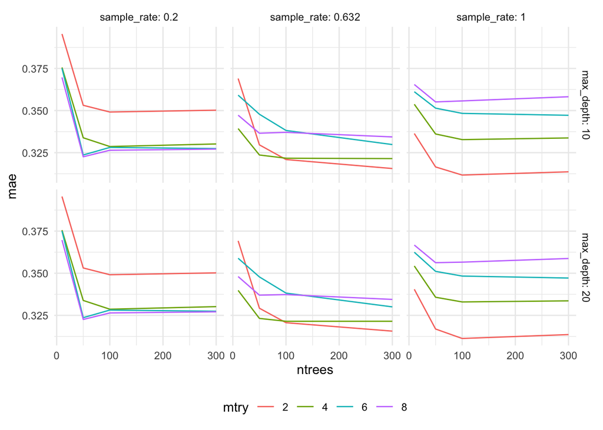

```r
rf_performance_summary <- h2o.getGrid(rf_grid@grid_id, "mae")@summary_table %>%
  as_tibble() %>%
  mutate(across(c("mae", names(rf_params)), as.numeric))
ggplot(rf_performance_summary, aes(ntrees, mae, color = factor(mtries))) +
  geom_line() +
  facet_grid(max_depth ~ sample_rate, labeller = label_both) +
  theme(legend.position = "bottom") +
  labs(color = "mtry")
```

### Variable importance

With the ensemble models we have a hard time with interpretation. Variable importance measures can help to see which features contribute most to the predictive power of models. Variable importance is determined by calculating the relative influence of each variable: whether that variable was selected to split on during the tree building process, and how much the squared error (over all trees) improved (decreased) as a result.

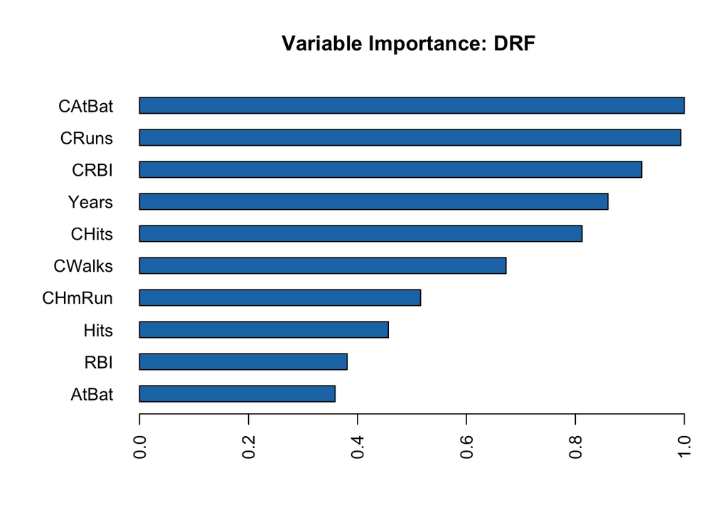

```r
h2o.varimp_plot(best_rf)
```

### Partial dependence

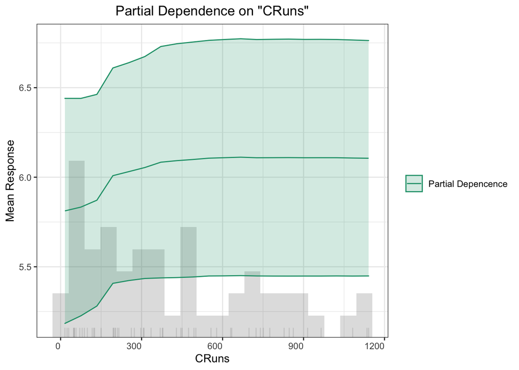

```r
h2o.pd_plot(best_rf, data_valid, "CRuns")
```

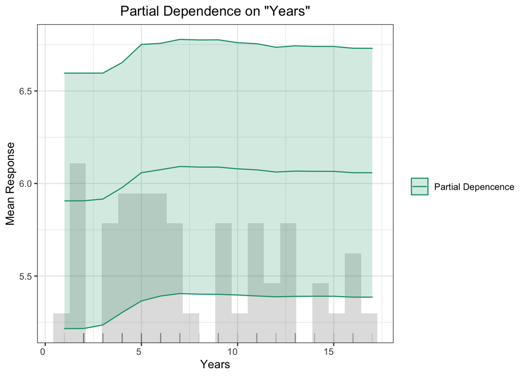

```r
h2o.pd_plot(best_rf, data_valid, "Years")
```

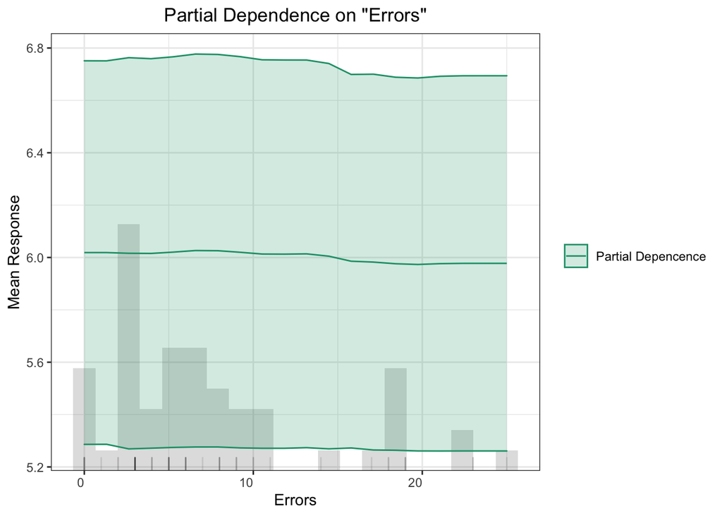

```r
h2o.pd_plot(best_rf, data_valid, "Errors")
```

I advise you to look at the [Model Explainability](https://docs.h2o.ai/h2o/latest-stable/h2o-docs/explain.html#) section of H2O’s documentation to see other tools that help you understand your model predictions.

## Gradient boosting machines

Gradient boosting machines: also ensembles of trees, however, the method of choosing them is different. Idea: get the residual and train next tree to predict (explain) the residual. Then add it to the previous trees, with a shrinkage parameter (to avoid overfitting). Thus, overall prediction is expected to improve. This is a boosting type algorithm. Boosting is building models (typically weak learners) sequentially, trying to improve the error of the previous models. [Here](https://quantdare.com/what-is-the-difference-between-bagging-and-boosting/) you can read further about the differences between bagging and boosting. Gradient boosting tries to improve on the gradient of the loss function which equals the residuals for regression problems with quadratic loss.

```r
simple_gbm <- h2o.gbm(
  x = X, y = y,
  model_id = "simple_gbm",
  training_frame = data_train,
  nfolds = 5,
  seed = my_seed
)
simple_gbm
```

```
## Model Details:
## ==============
##
## H2ORegressionModel: gbm
## Model ID:  simple_gbm
## Model Summary:
##   number_of_trees number_of_internal_trees model_size_in_bytes min_depth
## 1              50                       50                9443         4
##   max_depth mean_depth min_leaves max_leaves mean_leaves
## 1         5    4.96000          6         14    10.40000
##
##
## H2ORegressionMetrics: gbm
## ** Reported on training data. **
##
## MSE:  0.04924768
## RMSE:  0.2219182
## MAE:  0.124408
## RMSLE:  0.03184145
## Mean Residual Deviance :  0.04924768
##
##
##
## H2ORegressionMetrics: gbm
## ** Reported on cross-validation data. **
## ** 5-fold cross-validation on training data (Metrics computed for combined holdout predictions) **
##
## MSE:  0.260039
## RMSE:  0.5099402
## MAE:  0.3494235
## RMSLE:  0.07419138
## Mean Residual Deviance :  0.260039
##
##
## Cross-Validation Metrics Summary:
##                              mean          sd cv_1_valid cv_2_valid  cv_3_valid
## mae                    0.35208073 0.045182038  0.4177631 0.36656857  0.34379715
## mean_residual_deviance  0.2603132 0.095585145  0.2945894  0.2259467   0.2649996
## mse                     0.2603132 0.095585145  0.2945894  0.2259467   0.2649996
## r2                      0.6408724  0.13815147  0.5752968   0.736821  0.57396734
## residual_deviance       0.2603132 0.095585145  0.2945894  0.2259467   0.2649996
## rmse                   0.50263435  0.09792805  0.5427609  0.4753385   0.5147811
## rmsle                   0.0731421 0.014269185 0.07985254 0.06794778 0.077471256
##                        cv_4_valid  cv_5_valid
## mae                    0.29389855  0.33837628
## mean_residual_deviance 0.12732923  0.38870114
## mse                    0.12732923  0.38870114
## r2                      0.8289817   0.4892953
## residual_deviance      0.12732923  0.38870114
## rmse                    0.3568322  0.62345904
## rmsle                  0.05142315 0.089015774
```

```r
h2o.mae(h2o.performance(simple_gbm))
```

```
## [1] 0.124408
```

```r
h2o.mae(h2o.performance(simple_gbm, data_valid))
```

```
## [1] 0.347751
```

The variable importance profile is typically more extreme than for random forests. This is not a contradiction or a problem, just a property of the models and ultimately different faces of the data.

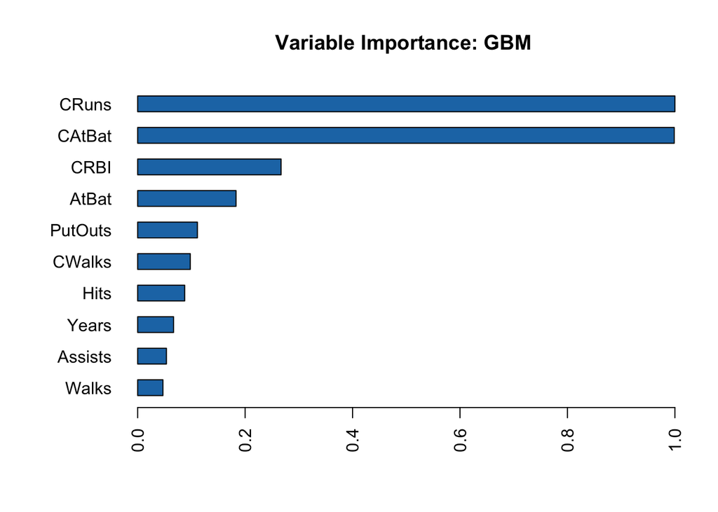

```r
h2o.varimp_plot(simple_gbm)
```

Let’s do some tuning

```r
gbm_params <- list(
  learn_rate = c(0.01, 0.05, 0.1, 0.3),  # default: 0.1
  ntrees = c(10, 50, 100, 300),
  max_depth = c(2, 5),
  sample_rate = c(0.2, 0.5, 0.8, 1)
)

gbm_grid <- h2o.grid(
  "gbm", x = X, y = y,
  grid_id = "gbm",
  training_frame = data_train,
  nfolds = 5,
  seed = my_seed,
  hyper_params = gbm_params
)
```

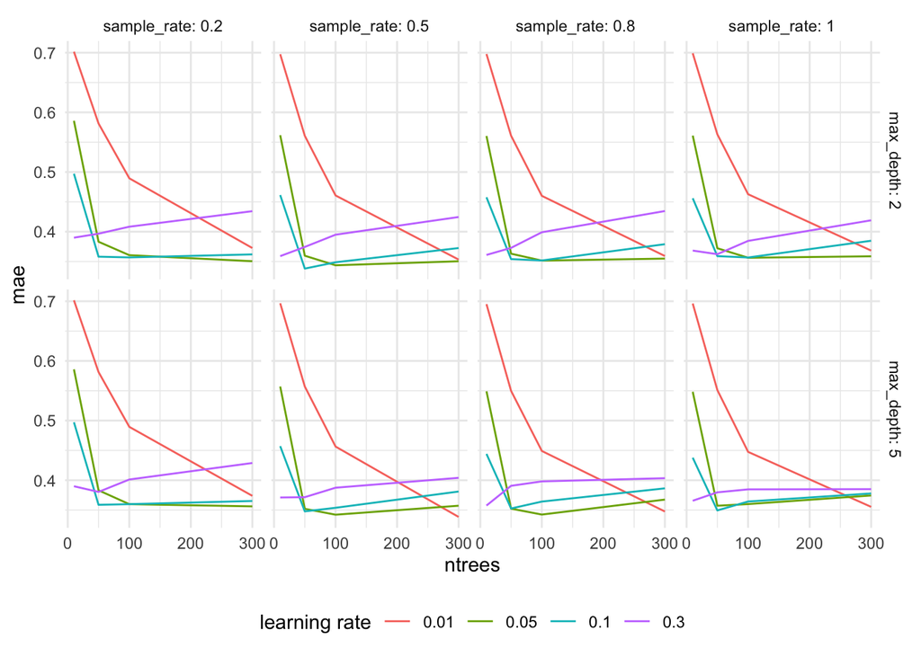

```r
gbm_performance_summary <- h2o.getGrid(gbm_grid@grid_id, "mae")@summary_table %>%
  as_tibble() %>%
  mutate(across(c("mae", names(gbm_params)), as.numeric))
ggplot(gbm_performance_summary, aes(ntrees, mae, color = factor(learn_rate))) +
  geom_line() +
  facet_grid(max_depth ~ sample_rate, labeller = label_both) +
  theme(legend.position = "bottom") +
  labs(color = "learning rate")
```

Lower learning rate (sometimes called “eta”) means slower learning, hence more trees are necessary to have good performance.

```r
best_gbm <- h2o.getModel(
  h2o.getGrid(gbm_grid@grid_id, "mae")@model_ids[[1]]
)
h2o.mae(h2o.performance(best_gbm))
```

```
## [1] 0.2424085
```

```r
h2o.mae(h2o.performance(best_gbm, data_valid))
```

```
## [1] 0.3515388
```

```r
gbm_manytree <- h2o.gbm(
  x = X, y = y,
  model_id = "gbm_manytree",
  training_frame = data_train,
  ntree = 500, learn_rate = 0.01, sample_rate = 0.5, max_depth = 5,
  nfolds = 5,
  seed = my_seed
)
h2o.mae(h2o.performance(gbm_manytree))
```

```
## [1] 0.1865219
```

```r
h2o.mae(h2o.performance(gbm_manytree, data_valid))
```

```
## [1] 0.3332368
```

### XGBoost

A celebrated implementation of the gradient boosting idea. *“Both xgboost and gbm follows the principle of gradient boosting. There are however, the difference in modeling details. Specifically, xgboost used a more regularized model formalization to control over-fitting, which gives it better performance.”*

See documentation [here](http://xgboost.readthedocs.io/). It proved to be very stable and widely applicable. For the many hyperparameters, consult the documentation.

Again, I recommend StatQuest videos that are doing a very good job in explaining complex algorithms simply, and have corresponding parts for all the methods we try here.

```r
simple_xgboost <- h2o.xgboost(
  x = X, y = y,
  model_id = "simple_xgboost",
  training_frame = data_train,
  nfolds = 5,
  seed = my_seed
)
simple_xgboost
```

```
## Model Details:
## ==============
##
## H2ORegressionModel: xgboost
## Model ID:  simple_xgboost
## Model Summary:
##   number_of_trees
## 1              50
##
##
## H2ORegressionMetrics: xgboost
## ** Reported on training data. **
##
## MSE:  1.089832e-05
## RMSE:  0.003301261
## MAE:  0.002369058
## RMSLE:  0.0004880012
## Mean Residual Deviance :  1.089832e-05
##
##
##
## H2ORegressionMetrics: xgboost
## ** Reported on cross-validation data. **
## ** 5-fold cross-validation on training data (Metrics computed for combined holdout predictions) **
##
## MSE:  0.3069513
## RMSE:  0.5540318
## MAE:  0.3723656
## RMSLE:  0.08022624
## Mean Residual Deviance :  0.3069513
##
##
## Cross-Validation Metrics Summary:
##                              mean          sd cv_1_valid cv_2_valid cv_3_valid
## mae                       0.37603  0.04001457 0.37612402 0.43735003 0.34809837
## mean_residual_deviance  0.3082457  0.11222394 0.28579953 0.32783473  0.2636208
## mse                     0.3082457  0.11222394 0.28579953 0.32783473  0.2636208
## r2                     0.58093256  0.14159432 0.58796895 0.61814344 0.57618403
## residual_deviance       0.3082457  0.11222394 0.28579953 0.32783473  0.2636208
## rmse                    0.5480856   0.0990449  0.5346022 0.57256854 0.51344013
## rmsle                  0.07919379 0.014539499 0.07800265 0.07922196 0.07688771
##                        cv_4_valid cv_5_valid
## mae                     0.3337565  0.3848211
## mean_residual_deviance  0.1797194  0.4842539
## mse                     0.1797194  0.4842539
## r2                      0.7586155  0.3637509
## residual_deviance       0.1797194  0.4842539
## rmse                   0.42393324  0.6958836
## rmsle                  0.06052203 0.10133461
```

```r
h2o.mae(h2o.performance(simple_xgboost))
```

```
## [1] 0.002369058
```

```r
h2o.mae(h2o.performance(simple_xgboost, data_valid))
```

```
## [1] 0.3964078
```

```r
xgboost_params <- list(
  learn_rate = c(0.1, 0.3),  # same as "eta", default: 0.3
  ntrees = c(50, 100),
  max_depth = c(2, 5),
  gamma = c(0, 1, 2),  # regularization parameter
  sample_rate = c(0.5, 1)
)

xgboost_grid <- h2o.grid(
  "xgboost", x = X, y = y,
  grid_id = "xgboost",
  training_frame = data_train,
  nfolds = 5,
  seed = my_seed,
  hyper_params = xgboost_params
)
best_xgboost <- h2o.getModel(
  h2o.getGrid(xgboost_grid@grid_id, "mae")@model_ids[[1]]
)
h2o.mae(h2o.performance(best_xgboost))
```

```
## [1] 0.1593339
```

```r
h2o.mae(h2o.performance(best_xgboost, data_valid))
```

```
## [1] 0.3608959
```

## Comparison of models

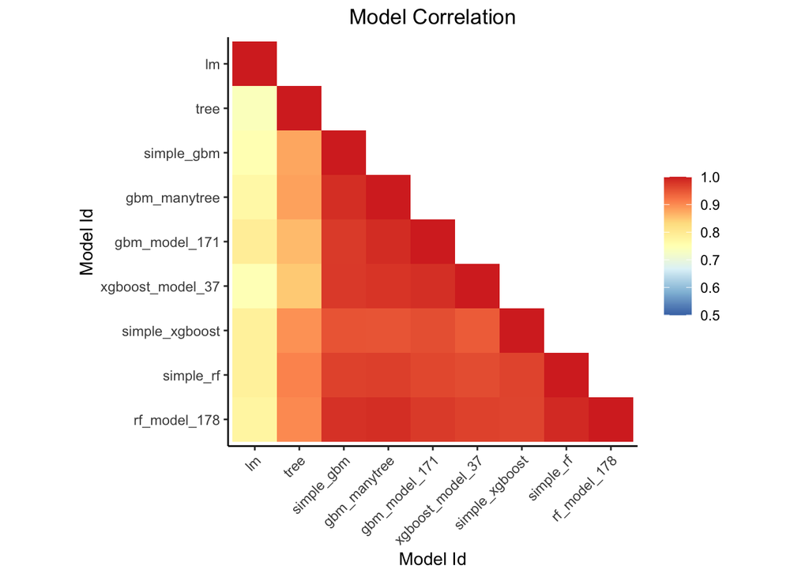

```r
my_models <- list(
  simple_lm, simple_tree, simple_rf, best_rf,
  simple_gbm, best_gbm, gbm_manytree, simple_xgboost,best_xgboost
)
mae_on_validation <- map_df(my_models, ~{
  tibble(model = .@model_id, MAE = h2o.mae(h2o.performance(., data_valid)))
}) %>% arrange(MAE)

h2o.model_correlation_heatmap(my_models, data_valid)
```

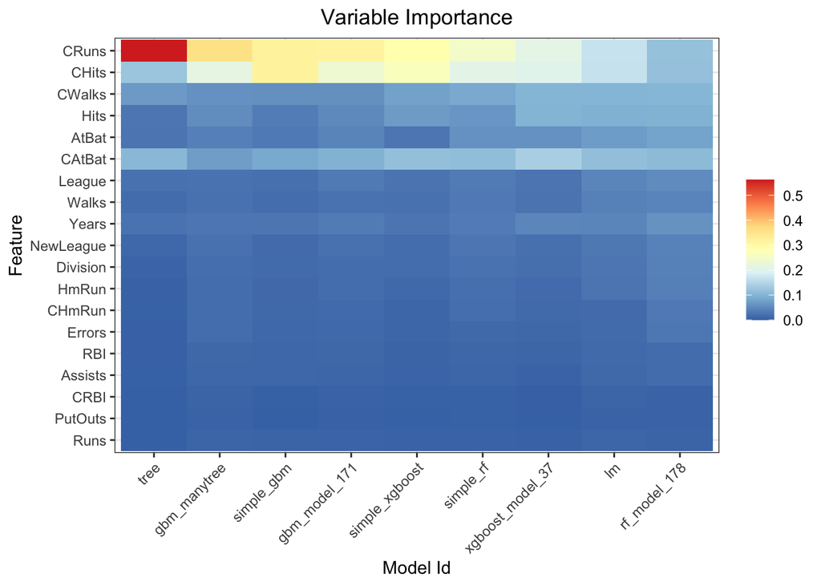

```r
h2o.varimp_heatmap(my_models)
```

## Compare to AutoML

```r
automl <- h2o.automl(
  X, y,
  training_frame = data_train,
  nfolds = 5,
  sort_metric = "MAE",
  seed = my_seed,
  max_runtime_secs = 60
)
```

```
##
## 18:43:28.85: Skipping training of model GBM_5_AutoML_20210301_184319 due to exception: water.exceptions.H2OModelBuilderIllegalArgumentException: Illegal argument(s) for GBM model: GBM_5_AutoML_20210301_184319.  Details: ERRR on field: _min_rows: The dataset size is too small to split for min_rows…
```

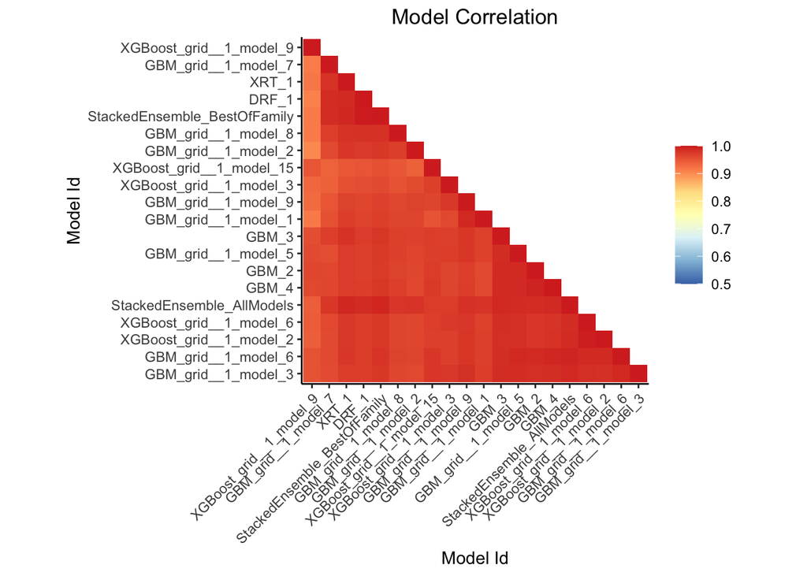

```r
h2o.model_correlation_heatmap(automl, data_valid)
```

```r
rbind(
  mae_on_validation,
  c("automl", h2o.mae(h2o.performance(automl@leader, data_valid)))
)
```

| model | MAE |
| --- | --- |
| gbm_manytree | 0.333236779159792 |
| rf_model_178 | 0.335691572855104 |
| simple_gbm | 0.347750999084244 |
| simple_rf | 0.348278897303455 |
| gbm_model_171 | 0.351538777270977 |
| xgboost_model_37 | 0.360895948589973 |
| simple_xgboost | 0.396407847134572 |
| tree | 0.459071726169226 |
| lm | 0.551004628570258 |
| automl | 0.359524825123595 |